# Figure7

# IBD

```r
source("custom_functions.R")
```

## Data Import

Importing ASV, taxa and metadata tables for both Czech and Norway samples.

**Czech**

*MICROBIOME*

```r
path = "../../data/analysis_ready_data/ikem/"
asv_tab_ikem <- as.data.frame(fread(file.path(path,"asv_table_ikem.csv"),
                                    check.names = FALSE))
taxa_tab_ikem <- as.data.frame(fread(file.path(path,"taxa_table_ikem.csv"),
                                     check.names = FALSE))
metadata_ikem <- as.data.frame(fread(file.path(path,"metadata_ikem.csv"),
                                     check.names = FALSE))
```

*IBD info*

```r
path = "../../data/clinical_data/"
cz <- read.csv(file.path(path,"clinical_metadata_cz.csv")) %>% dplyr::select(SampleID,PatientID,PSC_IBD,Group)

cz$PatientID <- as.character(cz$PatientID)
metadata_ikem <- merge(metadata_ikem,cz,by=c("SampleID", "Group"),all=TRUE)
```

**Norway**

*MICROBIOME*

```r
path = "../../data/analysis_ready_data/norway/"
asv_tab_norway <- as.data.frame(fread(file.path(path,"asv_table_norway.csv"),
                                    check.names = FALSE))
taxa_tab_norway <- as.data.frame(fread(file.path(path,"taxa_table_norway.csv"),
                                    check.names = FALSE))
metadata_norway <- as.data.frame(fread(file.path(path,"metadata_norway.csv"),
                                    check.names = FALSE))
```

*IBD info*

```r
path = "../../data/clinical_data/"
no <- read.csv(file.path(path,"clinical_metadata_no.csv")) %>% dplyr::select(SampleID,subjectid,IBD, Group)
```

### Merging

**Merging clinical metadata**

```r
clinical_metadata <- bind_rows(
  cz %>% dplyr::mutate(PSC_IBD = case_when(
    PSC_IBD == "0" ~ "no_ibd",
    PSC_IBD == "1" ~ "ibd",
  )) %>% `colnames<-`(c("SampleID","PatientID","IBD","Group")),
  no %>% `colnames<-`(c("SampleID","PatientID","IBD","Group")) %>%
    mutate(PatientID=paste0("NO_",PatientID)))
```

**Terminal ileum**

```r
ileum_data <- merging_data(asv_tab_1=asv_tab_ikem,
                           asv_tab_2=asv_tab_norway,
                           taxa_tab_1=taxa_tab_ikem,
                           taxa_tab_2=taxa_tab_norway,
                           metadata_1=metadata_ikem,
                           metadata_2=metadata_norway,
                           segment="TI",Q="Q3")
```

```
Removing 1498 ASV(s)
Removing 1834 ASV(s)
Merging at ASV level
Finding inconsistencies in taxonomy, trying to keep the ones that have better taxonomy assignment
Removing 979 ASV(s)
```

```r
ileum_asv_tab <- ileum_data[[1]]
ileum_taxa_tab <- ileum_data[[2]]
ileum_metadata <- ileum_data[[3]]

ileum_metadata <- merge(ileum_metadata,
                        clinical_metadata %>%
                          dplyr::select(-Group),
                        by=c("SampleID"), all.x = TRUE) %>%
  dplyr::select(-PatientID,Group) %>%
  dplyr::mutate(Group=IBD) %>% dplyr::select(-IBD)
```

**Colon**

```r
colon_data <- merging_data(asv_tab_1=asv_tab_ikem,
                           asv_tab_2=asv_tab_norway,
                           taxa_tab_1=taxa_tab_ikem,
                           taxa_tab_2=taxa_tab_norway,
                           metadata_1=metadata_ikem,
                           metadata_2=metadata_norway,
                           segment="colon",Q="Q3")
```

```
Removing 739 ASV(s)
Removing 266 ASV(s)
Merging at ASV level
Finding inconsistencies in taxonomy, trying to keep the ones that have better taxonomy assignment
Removing 1157 ASV(s)
```

```r
colon_asv_tab <- colon_data[[1]]
colon_taxa_tab <- colon_data[[2]]
colon_metadata <- colon_data[[3]]

colon_metadata <- merge(colon_metadata,
                        clinical_metadata %>%
                          dplyr::select(-Group),
                        by=c("SampleID"), all.x = TRUE) %>%
  dplyr::select(-PatientID,Group) %>%
  dplyr::mutate(Group=IBD) %>% dplyr::select(-IBD)
```

## Import clinical data

### CZ

```r
# clinical metadata
metadata_clinical <- read.csv("../../data/clinical_data/clinical_metadata_cz.csv")
metadata_clinical$PatientID <- as.character(metadata_clinical$PatientID)

# DYSBIOSIS
metadata_dysbiosis <- read.csv("../../data/clinical_data/dysbiosis_metadata.csv") %>%
  dplyr::filter(Country=="CZ")

# ALPHA DIVERSITY
metadata_alpha_ileum <- read.csv(
  "../results/Q1/alpha_diversity/alpha_indices_terminal_ileum.csv") %>%
  dplyr::filter(Country=="CZ")

metadata_alpha_colon <- read.csv(
  "../results/Q1/alpha_diversity/alpha_indices_colon.csv") %>%
  dplyr::filter(Country=="CZ")

metadata_alpha <- rbind(metadata_alpha_ileum,metadata_alpha_colon) %>%
  mutate(PatientID=Patient) %>%
  dplyr::select(-c(Patient, Group))

# MERGING
metadata_cz <- full_join(metadata_clinical, metadata_dysbiosis, by=c("SampleID","Matrix","PatientID","Group","Country"))

metadata_cz <- full_join(metadata_cz, metadata_alpha, by=c("SampleID","PatientID","Country"))

metadata_cz$Group <- factor(metadata_cz$Group,levels = c("healthy","pre_ltx","non-rPSC","rPSC"))
```

### NO

```r
# clinical metadata
metadata_clinical <- read.csv("../../data/clinical_data/clinical_metadata_no.csv")
metadata_clinical %<>% mutate(PatientID=subjectid,
                              Matrix=segment) %>%
  dplyr::select(-subjectid,-segment)
metadata_clinical$PatientID <- as.character(paste0("NO_",metadata_clinical$PatientID))

# DYSBIOSIS
metadata_dysbiosis <- read.csv("../../data/clinical_data/dysbiosis_metadata.csv") %>%
  dplyr::filter(Country=="NO")  %>%
  dplyr::select(-c(Patient))

# ALPHA DIVERSITY
metadata_alpha_ileum <- read.csv(
  "../results/Q1/alpha_diversity/alpha_indices_terminal_ileum.csv") %>%
  dplyr::filter(Country=="NO")

metadata_alpha_colon <- read.csv(
  "../results/Q1/alpha_diversity/alpha_indices_colon.csv") %>%
  dplyr::filter(Country=="NO")

metadata_alpha <- rbind(metadata_alpha_ileum,metadata_alpha_colon) %>%
  mutate(PatientID=Patient) %>%
  dplyr::select(-c(Patient, Group))

# MERGING
metadata_no <- full_join(metadata_clinical, metadata_dysbiosis, by=c("SampleID","Matrix","PatientID","Group","Country"))

metadata_no <- full_join(metadata_no, metadata_alpha, by=c("SampleID","PatientID","Country"))

metadata_no$Group <- factor(metadata_no$Group,levels = c("healthy","pre_ltx","non-rPSC","rPSC"))
```

### Merging metadata

```r
metadata_cz %<>% dplyr::mutate(Calprotectin=Fecal.calprotectin,
                             AOM=AOM_score,
                             APRI=APRI_score,
                             FIB4=FIB4_score) %>%
  dplyr::select(SampleID,Matrix,PatientID,Group,Country,Bilirubin,ALP,Calprotectin,
                MAYO_PSC,AOM,APRI,FIB4,Platelets,AST,Creatinine,
                Albumin,ALT,PSC_IBD,GGT,INR,Albumin,Nancy_max,eMAYO,MAYO_dai,
                dys_unfiltered_asv,dys_unfiltered_genus,
                dys_filtered_asv,dys_filtered_genus,
                Observe,Shannon,Simpson,Pielou)

metadata_no %<>% dplyr::mutate(Platelets=TRC,
                             Creatinine=Kreatinin,
                             MAYO_PSC=Mayo_score,
                             AST=ASAT/60,
                             ALT=ALAT/60,
                             PSC_IBD=IBD,
                             Bilirubin=Bilirubin*17.1,
                             ALP=ALP/60,
                             Albumin=Albumin*10) %>%
  dplyr::mutate(PSC_IBD = case_when(
      PSC_IBD == "no_ibd" ~ "0",
      PSC_IBD == "ibd" ~ "1",
      TRUE ~ Group  # Keep other values as is
    )) %>%
  dplyr::select(SampleID,Matrix,PatientID,Group,Country,Bilirubin,ALP,Calprotectin,
                MAYO_PSC,AOM,APRI,FIB4,Platelets,AST,Creatinine,
                Albumin,ALT,PSC_IBD,
                dys_unfiltered_asv,dys_unfiltered_genus,
                dys_filtered_asv,dys_filtered_genus,
                Observe,Shannon,Simpson,Pielou)

metadata_final <- merge(metadata_cz,metadata_no,all = TRUE)
metadata_final$Calprotectin[metadata_final$Calprotectin==">6000"] <- 6000
metadata_final$Calprotectin <- as.numeric(metadata_final$Calprotectin)
```

# Data Analysis - Terminal ileum

```r
segment="terminal_ileum"
```

## Filtering

Rules:

- sequencing depth > 10000
- nearZeroVar() with default settings

**Rarefaction Curve**

```r
path="../intermediate_files/rarecurves"
seq_depth_threshold <- 10000
```

```r
ps <- construct_phyloseq(ileum_asv_tab,ileum_taxa_tab,ileum_metadata)
rareres <- get_rarecurve(obj=ps, chunks=500)
save(rareres,file = file.path(path,"rarefaction_ileum.Rdata"))
```

```r
load(file.path(path,"rarefaction_ileum.Rdata"))

prare <- ggrarecurve(obj=rareres,
                      factorNames="Country",
                      indexNames=c("Observe")) +
  theme_bw() +
  theme(axis.text=element_text(size=8), panel.grid=element_blank(),
        strip.background = element_rect(colour=NA,fill="grey"),
        strip.text.x = element_text(face="bold")) +
  geom_vline(xintercept = seq_depth_threshold,
             linetype="dashed",
             color = "red") +
  xlim(0, 20000)
```

```
The color has been set automatically, you can reset it manually by adding scale_color_manual(values=yourcolors)
```

```r
prare
```

[output not shown]

**Library size**

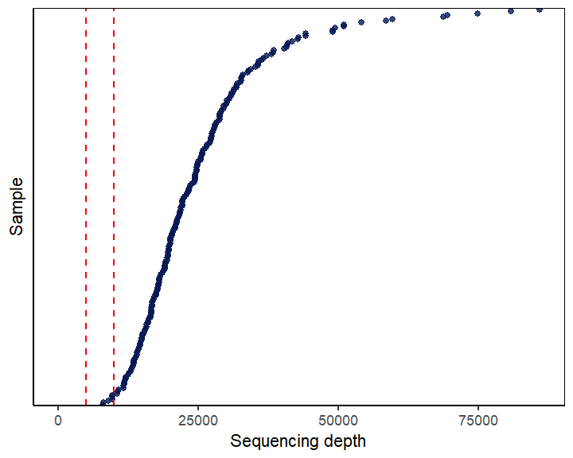

```r
read_counts(ileum_asv_tab, line = c(5000,10000))
```

### Sequencing depth

```r
data_filt <- seq_depth_filtering(ileum_asv_tab,
                                 ileum_taxa_tab,
                                 ileum_metadata,
                                 seq_depth_threshold = 10000)
```

```
Removing 68 ASV(s)
```

```r
filt_ileum_asv_tab <- data_filt[[1]]; alpha_ileum_asv_tab <- filt_ileum_asv_tab
filt_ileum_taxa_tab <- data_filt[[2]]; alpha_ileum_taxa_tab <- filt_ileum_taxa_tab
filt_ileum_metadata <- data_filt[[3]]; alpha_ileum_metadata <- filt_ileum_metadata

seq_step <- dim(filt_ileum_asv_tab)[1]
```

**Library size**

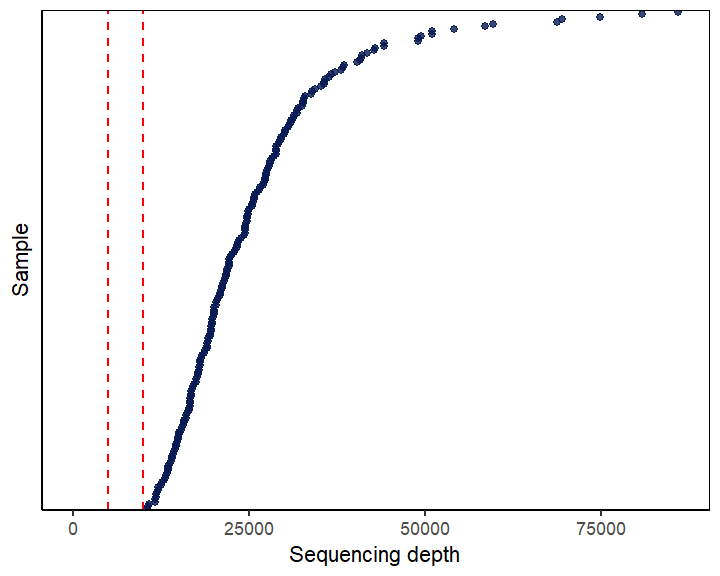

```r
read_counts(filt_ileum_asv_tab,line = c(5000,10000))
```

### NearZeroVar

```r
data_filt <- nearzerovar_filtering(filt_ileum_asv_tab,
                                   filt_ileum_taxa_tab,
                                   filt_ileum_metadata)

filt_ileum_asv_tab <- data_filt[[1]]
filt_ileum_taxa_tab <- data_filt[[2]]
nearzero_step <- dim(filt_ileum_asv_tab)[1]
```

Library size

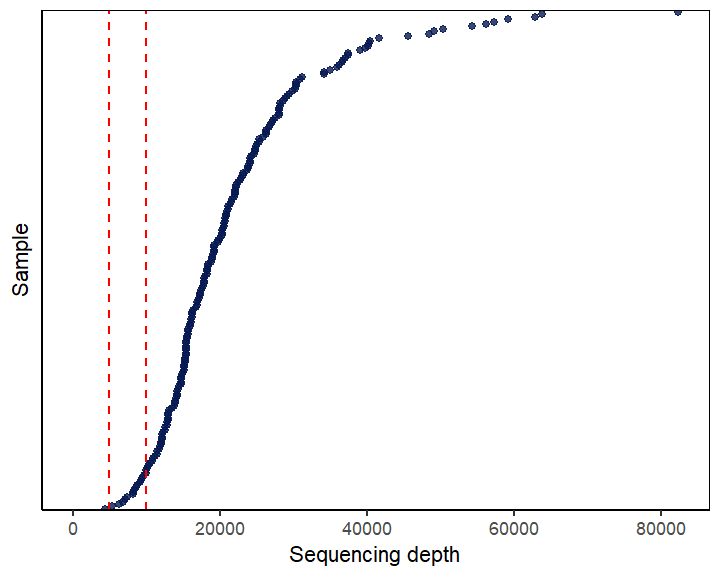

```r
read_counts(filt_ileum_asv_tab,line = c(5000,10000))
```

### Final Counts

```r
final_counts_filtering(ileum_asv_tab,
                       filt_ileum_asv_tab,
                       filt_ileum_metadata,
                       seq_step, 0, nearzero_step) %>% `colnames<-`("Count")
```

|  | Count |
| --- | --- |
| Raw data: ASVs | 4153 |
| Raw data: Samples | 214 |
| Sequencing depth filt: ASVs | 4085 |
| Prevalence filt: ASVs | 0 |
| NearZeroVar filt: ASVs | 449 |
| Filt data: ASVs | 449 |
| Filt data: Samples | 208 |
| Filt data: Patients | 208 |
| Filt data: Patients.1 | 0 |
| Filtered samples | 6 |

[output cut: 7 more lines]

## Alpha diversity

```r
path = "../results/Q3/alpha_diversity"
```

**Calculation**

```r
# Construct MPSE object
alpha_ileum_metadata$Sample <- alpha_ileum_metadata$SampleID
ileum_mpse <- as.MPSE(construct_phyloseq(alpha_ileum_asv_tab,
                                         alpha_ileum_taxa_tab,
                                         alpha_ileum_metadata))

ileum_mpse %<>% mp_rrarefy(raresize = 10000,seed = 123)

# Calculate alpha diversity - rarefied counts
ileum_mpse %<>% mp_cal_alpha(.abundance=RareAbundance, force=TRUE)
```

```r
alpha_div_plots_ibd <- list()

# preparing data frame
alpha_data_ibd <- data.frame(SampleID=ileum_mpse$Sample.x,
                         Observe=ileum_mpse$Observe,
                         Shannon=ileum_mpse$Shannon,
                         Simpson=ileum_mpse$Simpson,
                         Pielou=ileum_mpse$Pielou,
                         Group=ileum_mpse$Group,
                         Country=ileum_mpse$Country,
                         Patient=ileum_mpse$Patient)
```

### Plots

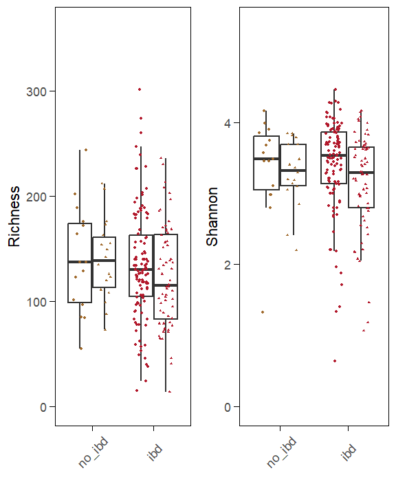

```r
p_boxplot_alpha <- alpha_diversity_countries(alpha_data_ibd,show_legend = FALSE)
# save the results
alpha_div_plots_ibd[[paste(segment,"Country")]] <- p_boxplot_alpha

# see the results
p_boxplot_alpha
```

## Beta diversity

### Main analysis

**Genus level, Aitchison distance**

```r
level="genus"
```

```r
pca_plots_list_ibd <- list()
```

Aggregation, filtering

```r
# Aggregation
genus_data <- aggregate_taxa(ileum_asv_tab,
                             ileum_taxa_tab,
                             taxonomic_level=level,
                             names=TRUE)
# Filtration
filt_data <- filtering_steps(genus_data[[1]],
                             genus_data[[2]],
                             ileum_metadata,
                             seq_depth_threshold=10000)
```

```
Removing 6 ASV(s)
```

```r
filt_ileum_genus_tab <- filt_data[[1]]
filt_ileum_genus_taxa <- filt_data[[2]]
filt_ileum_metadata <- filt_data[[3]]
```

##### Plots

**PCA**

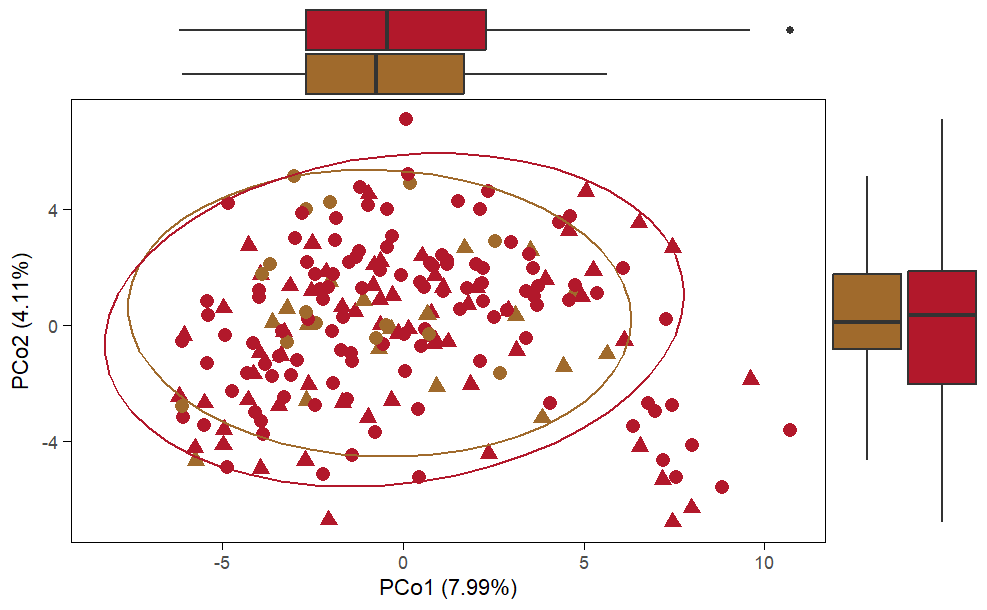

```r
p <- pca_plot_custom(filt_ileum_genus_tab,
                                 filt_ileum_genus_taxa,
                                 filt_ileum_metadata,
                                 show_boxplots = TRUE,
                                 variable = "Group", size=3, show_legend=FALSE)

# save the results
pca_plots_list_ibd[[paste(segment,level,"custom")]] <- p

# see the results
p
```

# Data Analysis - Colon

```r
segment="colon"
```

## Filtering

Library size

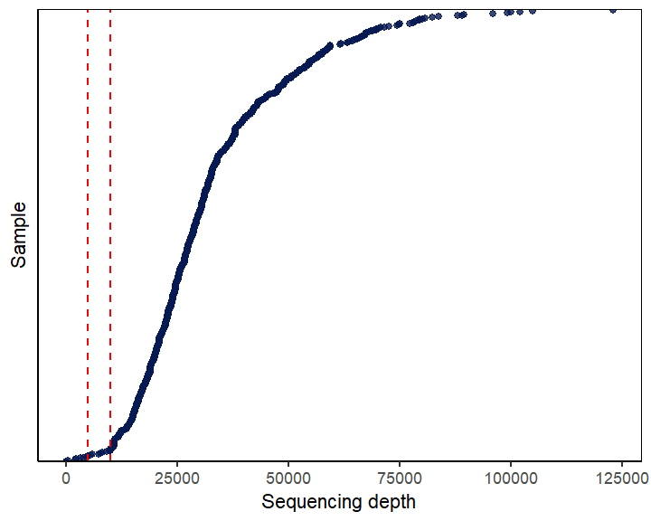

```r
read_counts(colon_asv_tab, line = c(5000,10000))
```

### Sequencing depth

```r
data_filt <- seq_depth_filtering(colon_asv_tab,
                                 colon_taxa_tab,
                                 colon_metadata,
                                 seq_depth_threshold = 10000)
```

```
Removing 52 ASV(s)
```

```r
filt_colon_asv_tab <- data_filt[[1]]; alpha_colon_asv_tab <- filt_colon_asv_tab
filt_colon_taxa_tab <- data_filt[[2]]; alpha_colon_taxa_tab <- filt_colon_taxa_tab
filt_colon_metadata <- data_filt[[3]]; alpha_colon_metadata <- filt_colon_metadata

seq_step <- dim(filt_colon_asv_tab)[1]
```

Library size

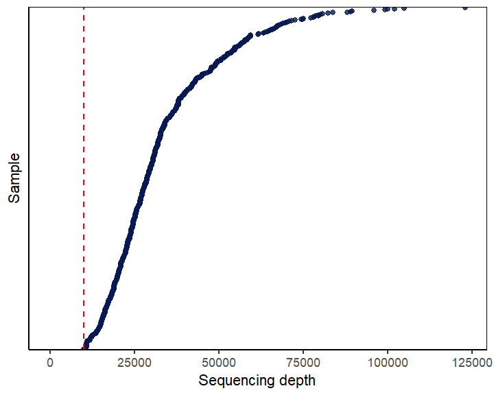

```r
read_counts(filt_colon_asv_tab,line = c(10000))
```

### NearZeroVar

```r
data_filt <- nearzerovar_filtering(filt_colon_asv_tab,
                                   filt_colon_taxa_tab,
                                   filt_colon_metadata)

filt_colon_asv_tab <- data_filt[[1]]
filt_colon_taxa_tab <- data_filt[[2]]
nearzero_step <- dim(filt_colon_asv_tab)[1]
```

Library size

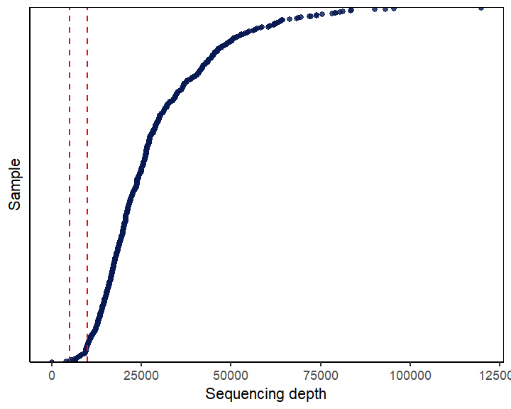

```r
read_counts(filt_colon_asv_tab,line = c(5000,10000))
```

Check zero depth

```r
data_filt <- check_zero_depth(filt_colon_asv_tab,
                              filt_colon_taxa_tab,
                              filt_colon_metadata)

filt_colon_asv_tab <- data_filt[[1]];
filt_colon_taxa_tab <- data_filt[[2]];
filt_colon_metadata <- data_filt[[3]];
```

Library size

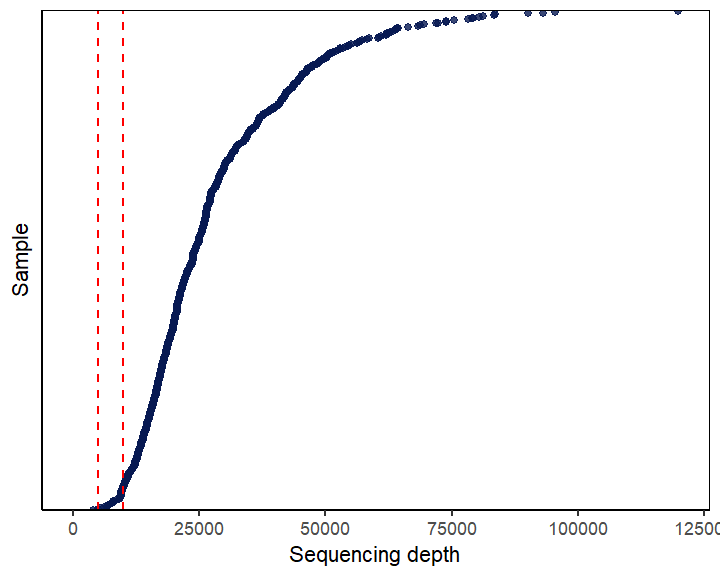

```r
read_counts(filt_colon_asv_tab,line = c(5000,10000))
```

### Final Counts

```r
final_counts_filtering(colon_asv_tab,
                       filt_colon_asv_tab,
                       filt_colon_metadata,
                       seq_step, 0, nearzero_step)
```

|  | V1 |
| --- | --- |
| Raw data: ASVs | 5779 |
| Raw data: Samples | 616 |
| Sequencing depth filt: ASVs | 5727 |
| Prevalence filt: ASVs | 0 |
| NearZeroVar filt: ASVs | 306 |
| Filt data: ASVs | 306 |
| Filt data: Samples | 599 |
| Filt data: Patients | 263 |
| Filt data: Patients.1 | 0 |
| Filtered samples | 17 |

[output cut: 7 more lines]

## Alpha diversity

```r
path = "../results/Q3/alpha_diversity"
```

**Calculation**

```r
# Construct MPSE object
alpha_colon_metadata$Sample <- alpha_colon_metadata$SampleID
colon_mpse <- as.MPSE(construct_phyloseq(alpha_colon_asv_tab,
                                         alpha_colon_taxa_tab,
                                         alpha_colon_metadata))

colon_mpse %<>% mp_rrarefy(raresize = 10000,seed = 123)

# Calculate alpha diversity - rarefied counts
colon_mpse %<>% mp_cal_alpha(.abundance=RareAbundance, force=TRUE)
```

```r
alpha_data_ibd <- data.frame(SampleID=colon_mpse$Sample.x,
                         Observe=colon_mpse$Observe,
                         Shannon=colon_mpse$Shannon,
                         Simpson=colon_mpse$Simpson,
                         Pielou=colon_mpse$Pielou,
                         Group=colon_mpse$Group,
                         Country=colon_mpse$Country,
                         Patient=colon_mpse$Patient)
```

### Plots

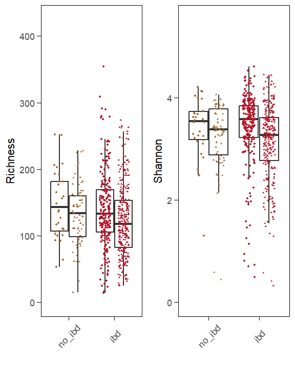

```r
p_boxplot_alpha <- alpha_diversity_countries(alpha_data_ibd)
# save the results
alpha_div_plots_ibd[[paste(segment,"Country")]] <- p_boxplot_alpha

# see the results
p_boxplot_alpha
```

## Beta diversity

### Main analysis - Genus, Aitchison

**Genus level, Aitchison distance**

```r
level="genus"
```

Aggregation, filtering

```r
genus_data <- aggregate_taxa(colon_asv_tab,
                             colon_taxa_tab,
                             taxonomic_level=level,
                             names=TRUE)

filt_data <- filtering_steps(genus_data[[1]],
                             genus_data[[2]],
                             colon_metadata,
                            seq_depth_threshold=10000)
```

```
Removing 10 ASV(s)
```

```r
filt_colon_genus_tab <- filt_data[[1]]
filt_colon_genus_taxa <- filt_data[[2]]
filt_colon_genus_metadata <- filt_data[[3]]
```

##### Plots

**PCoA custom**

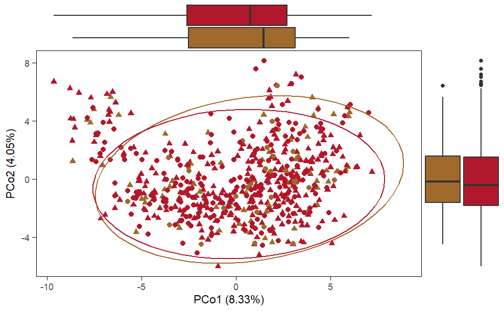

```r
p <- pca_plot_custom(filt_colon_genus_tab,
                                 filt_colon_genus_taxa,
                                 filt_colon_genus_metadata,
                                 show_boxplots = TRUE,
                                 variable = "Group", size=2,
                                 show_legend=FALSE)

# save the results
pca_plots_list_ibd[[paste(segment,level,"custom")]] <- p

# see the results
p
```

# Nancy

## Data Import

**Czech**

*MICROBIOME*

```r
path = "../../data/analysis_ready_data/ikem/"
asv_tab_ikem <- as.data.frame(fread(file.path(path,"asv_table_ikem.csv"),
                                    check.names = FALSE))
taxa_tab_ikem <- as.data.frame(fread(file.path(path,"taxa_table_ikem.csv"),
                                     check.names = FALSE))
metadata_ikem <- as.data.frame(fread(file.path(path,"metadata_ikem.csv"),
                                     check.names = FALSE))
```

*Nancy_max info*

```r
# clinical metadata
metadata_clinical <- read.csv("../../data/clinical_data/clinical_metadata_cz.csv")
metadata_clinical$PatientID <- as.character(metadata_clinical$PatientID)
```

### Merging

**Clinical data**

```r
metadata_ikem <- merge(metadata_ikem,metadata_clinical[,c("SampleID","Nancy_max")],by="SampleID",all.x=TRUE)
```

**Terminal ileum**

```r
ileum_data <- merging_data(asv_tab_1=asv_tab_ikem,
                           asv_tab_2= NULL,
                           taxa_tab_1=taxa_tab_ikem,
                           taxa_tab_2=NULL,
                           metadata_1=metadata_ikem,
                           metadata_2=NULL,
                           segment="TI",Q="Q4")
```

```
Removing 1498 ASV(s)
```

```r
ileum_asv_tab <- ileum_data[[1]]
ileum_taxa_tab <- ileum_data[[2]]
ileum_metadata <- ileum_data[[3]]

ileum_metadata <- merge(ileum_metadata,metadata_ikem[,c("SampleID","Nancy_max")],by="SampleID",all.x=TRUE) %>% dplyr::mutate(Nancy = case_when(
    Nancy_max %in% c(0,1) ~ "low",
    Nancy_max %in% c(2,3,4,5) ~ "high"))

ileum_metadata %<>% drop_na(Nancy)
ileum_asv_tab %<>% dplyr::select("SeqID",ileum_metadata$SampleID)
ileum_taxa_tab %<>% dplyr::filter(SeqID %in% ileum_asv_tab$SeqID)
```

**Colon**

```r
colon_data <- merging_data(asv_tab_1=asv_tab_ikem,
                           asv_tab_2=NULL,
                           taxa_tab_1=taxa_tab_ikem,
                           taxa_tab_2=NULL,
                           metadata_1=metadata_ikem,
                           metadata_2=NULL,
                           segment="colon",Q="Q4")
```

```
Removing 739 ASV(s)
```

```r
colon_asv_tab <- colon_data[[1]]
colon_taxa_tab <- colon_data[[2]]
colon_metadata <- colon_data[[3]]

colon_metadata <- merge(colon_metadata,metadata_ikem[,c("SampleID","Nancy_max")],by="SampleID",all.x=TRUE) %>% dplyr::mutate(Nancy = case_when(
    Nancy_max %in% c(0,1) ~ "low",
    Nancy_max %in% c(2,3,4,5) ~ "high"))

colon_metadata %<>% drop_na(Nancy)
colon_asv_tab %<>% dplyr::select("SeqID",colon_metadata$SampleID)
colon_taxa_tab %<>% dplyr::filter(SeqID %in% colon_asv_tab$SeqID)
```

# Data Analysis - Terminal ileum

```r
segment="terminal_ileum"
```

## Filtering

Rules:

- sequencing depth > 10000
- nearZeroVar() with default settings

**Rarefaction Curve**

```r
path="../intermediate_files/rarecurves"
seq_depth_threshold <- 10000
```

```r
ps <- construct_phyloseq(ileum_asv_tab,ileum_taxa_tab,ileum_metadata)
rareres <- get_rarecurve(obj=ps, chunks=500)
save(rareres,file = file.path(path,"rarefaction_ileum.Rdata"))
```

```r
load(file.path(path,"rarefaction_ileum.Rdata"))

prare <- ggrarecurve(obj=rareres,
                      factorNames="Country",
                      indexNames=c("Observe")) +
  theme_bw() +
  theme(axis.text=element_text(size=8), panel.grid=element_blank(),
        strip.background = element_rect(colour=NA,fill="grey"),
        strip.text.x = element_text(face="bold")) +
  geom_vline(xintercept = seq_depth_threshold,
             linetype="dashed",
             color = "red") +
  xlim(0, 20000)
```

```
The color has been set automatically, you can reset it manually by adding scale_color_manual(values=yourcolors)
```

```r
prare
```

[output not shown]

**Library size**

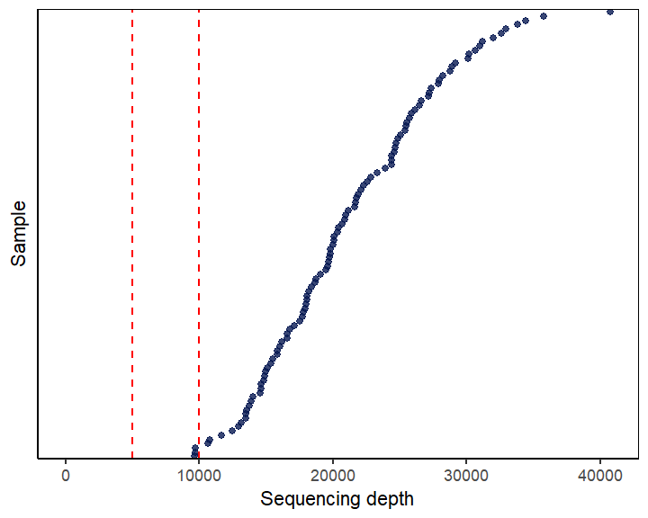

```r
read_counts(ileum_asv_tab, line = c(5000,10000))
```

### Sequencing depth

```r
data_filt <- seq_depth_filtering(ileum_asv_tab,
                                 ileum_taxa_tab,
                                 ileum_metadata,
                                 seq_depth_threshold = 10000)
```

```
Removing 861 ASV(s)
```

```r
filt_ileum_asv_tab <- data_filt[[1]]; alpha_ileum_asv_tab <- filt_ileum_asv_tab
filt_ileum_taxa_tab <- data_filt[[2]]; alpha_ileum_taxa_tab <- filt_ileum_taxa_tab
filt_ileum_metadata <- data_filt[[3]]; alpha_ileum_metadata <- filt_ileum_metadata

seq_step <- dim(filt_ileum_asv_tab)[1]
```

**Library size**

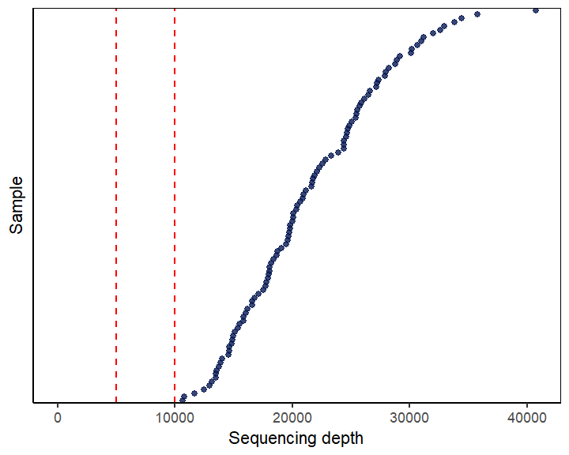

```r
read_counts(filt_ileum_asv_tab,line = c(5000,10000))
```

### NearZeroVar

```r
data_filt <- nearzerovar_filtering(filt_ileum_asv_tab,
                                   filt_ileum_taxa_tab,
                                   filt_ileum_metadata)

filt_ileum_asv_tab <- data_filt[[1]]
filt_ileum_taxa_tab <- data_filt[[2]]
nearzero_step <- dim(filt_ileum_asv_tab)[1]
```

Library size

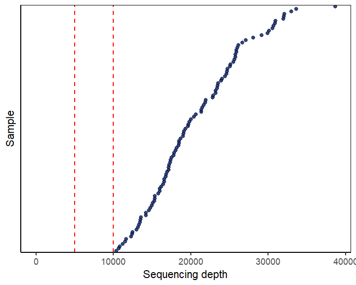

```r
read_counts(filt_ileum_asv_tab,line = c(5000,10000))
```

### Final Counts

```r
final_counts_filtering(ileum_asv_tab,
                       filt_ileum_asv_tab,
                       filt_ileum_metadata,
                       seq_step, 0, nearzero_step) %>% `colnames<-`("Count")
```

|  | Count |
| --- | --- |
| Raw data: ASVs | 3661 |
| Raw data: Samples | 106 |
| Sequencing depth filt: ASVs | 2800 |
| Prevalence filt: ASVs | 0 |
| NearZeroVar filt: ASVs | 1596 |
| Filt data: ASVs | 1596 |
| Filt data: Samples | 103 |
| Filt data: Patients | 103 |
| Filt data: Patients.1 | 0 |
| Filtered samples | 3 |

[output cut: 7 more lines]

## Alpha diversity

```r
path = "../results/Q4/alpha_diversity"
```

**Calculation**

```r
# Construct MPSE object
alpha_ileum_metadata$Sample <- alpha_ileum_metadata$SampleID
ileum_mpse <- as.MPSE(construct_phyloseq(alpha_ileum_asv_tab,
                                         alpha_ileum_taxa_tab,
                                         alpha_ileum_metadata))

ileum_mpse %<>% mp_rrarefy(raresize = 10000,seed = 123)

# Calculate alpha diversity - rarefied counts
ileum_mpse %<>% mp_cal_alpha(.abundance=RareAbundance, force=TRUE)
```

```r
alpha_div_plots_nancy <- list()

# preparing data frame
alpha_data_nancy <- data.frame(SampleID=ileum_mpse$Sample.x,
                         Observe=ileum_mpse$Observe,
                         Shannon=ileum_mpse$Shannon,
                         Simpson=ileum_mpse$Simpson,
                         Pielou=ileum_mpse$Pielou,
                         Group=ileum_mpse$Nancy,
                         Country=ileum_mpse$Country,
                         Patient=ileum_mpse$Patient)

alpha_data_nancy %<>% drop_na()
```

### Plots

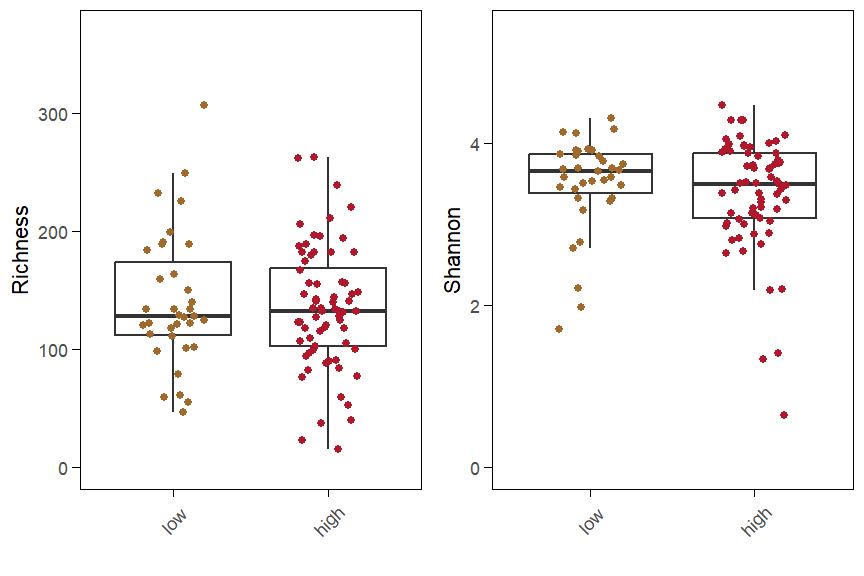

```r
p_boxplot_alpha <- alpha_diversity_custom_2(alpha_data_nancy)
# save the results
alpha_div_plots_nancy[[paste(segment,"Custom")]] <- p_boxplot_alpha

# see the results
p_boxplot_alpha
```

## Beta diversity

### Main analysis

**Genus level, Aitchison distance**

```r
level="genus"
```

```r
pca_plots_list_nancy <- list()
```

Aggregation, filtering

```r
# Aggregation
genus_data <- aggregate_taxa(ileum_asv_tab,
                             ileum_taxa_tab,
                             taxonomic_level=level,
                             names=TRUE)
# Filtration
filt_data <- filtering_steps(genus_data[[1]],
                             genus_data[[2]],
                             ileum_metadata,
                             seq_depth_threshold=10000)
```

```
Removing 56 ASV(s)
```

```r
filt_ileum_genus_tab <- filt_data[[1]]
filt_ileum_genus_taxa <- filt_data[[2]]
filt_ileum_metadata <- filt_data[[3]]

filt_ileum_metadata %<>% dplyr::mutate(Group=Nancy)
```

##### Plots

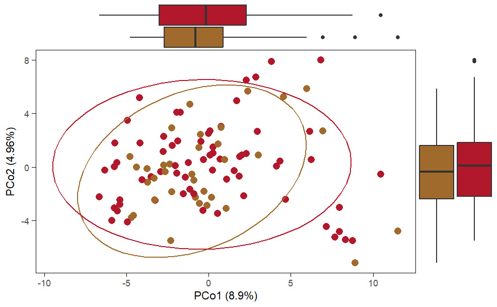

```r
p <- pca_plot_custom(filt_ileum_genus_tab,
                                 filt_ileum_genus_taxa,
                                 filt_ileum_metadata,
                                 show_boxplots = TRUE,
                                 variable = "Group", size=3, show_legend=FALSE)

# save the results
pca_plots_list_nancy[[paste(segment,level,"custom")]] <- p

# see the results
p
```

# Data Analysis - Colon

```r
segment="colon"
```

## Filtering

Rules:

- sequencing depth > 10000
- nearZeroVar() with default settings

**Rarefaction Curve**

```r
path="../intermediate_files/rarecurves"
seq_depth_threshold <- 10000
```

```r
ps <- construct_phyloseq(colon_asv_tab,colon_taxa_tab,colon_metadata)
rareres <- get_rarecurve(obj=ps, chunks=500)
save(rareres,file = file.path(path,"rarefaction_colon.Rdata"))
```

```r
load(file.path(path,"rarefaction_colon.Rdata"))

prare <- ggrarecurve(obj=rareres,
                      factorNames="Country",
                      indexNames=c("Observe")) +
  theme_bw() +
  theme(axis.text=element_text(size=8), panel.grid=element_blank(),
        strip.background = element_rect(colour=NA,fill="grey"),
        strip.text.x = element_text(face="bold")) +
  geom_vline(xintercept = seq_depth_threshold,
             linetype="dashed",
             color = "red") +
  xlim(0, 20000)
```

```
The color has been set automatically, you can reset it manually by adding scale_color_manual(values=yourcolors)
```

[figure not shown]

```r
prare
```

**Library size**

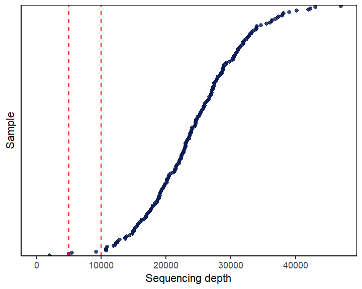

```r
read_counts(colon_asv_tab, line = c(5000,10000))
```

### Sequencing depth

```r
data_filt <- seq_depth_filtering(colon_asv_tab,
                                 colon_taxa_tab,
                                 colon_metadata,
                                 seq_depth_threshold = 10000)
```

```
Removing 1082 ASV(s)
```

```r
filt_colon_asv_tab <- data_filt[[1]]; alpha_colon_asv_tab <- filt_colon_asv_tab
filt_colon_taxa_tab <- data_filt[[2]]; alpha_colon_taxa_tab <- filt_colon_taxa_tab
filt_colon_metadata <- data_filt[[3]]; alpha_colon_metadata <- filt_colon_metadata

seq_step <- dim(filt_colon_asv_tab)[1]
```

**Library size**

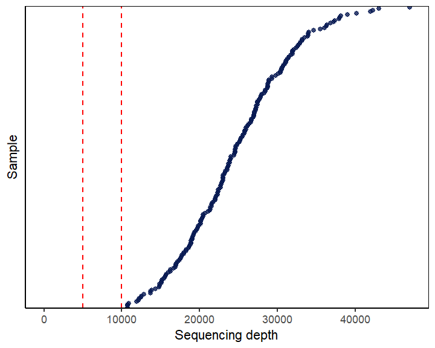

```r
read_counts(filt_colon_asv_tab,line = c(5000,10000))
```

### NearZeroVar

```r
data_filt <- nearzerovar_filtering(filt_colon_asv_tab,
                                   filt_colon_taxa_tab,
                                   filt_colon_metadata)

filt_colon_asv_tab <- data_filt[[1]]
filt_colon_taxa_tab <- data_filt[[2]]
nearzero_step <- dim(filt_colon_asv_tab)[1]
```

Library size

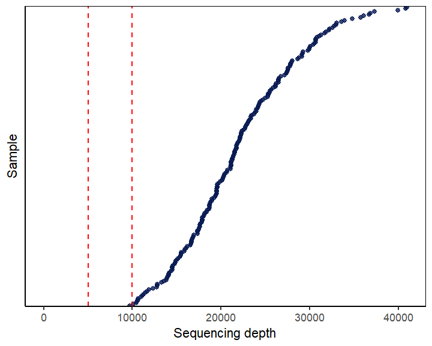

```r
read_counts(filt_colon_asv_tab,line = c(5000,10000))
```

### Final Counts

```r
final_counts_filtering(colon_asv_tab,
                       filt_colon_asv_tab,
                       filt_colon_metadata,
                       seq_step, 0, nearzero_step) %>% `colnames<-`("Count")
```

|  | Count |
| --- | --- |
| Raw data: ASVs | 4420 |
| Raw data: Samples | 212 |
| Sequencing depth filt: ASVs | 3338 |
| Prevalence filt: ASVs | 0 |
| NearZeroVar filt: ASVs | 713 |
| Filt data: ASVs | 713 |
| Filt data: Samples | 208 |
| Filt data: Patients | 109 |
| Filt data: Patients.1 | 0 |
| Filtered samples | 4 |

[output cut: 7 more lines]

## Alpha diversity

```r
path = "../results/Q4/alpha_diversity"
```

**Calculation**

```r
# Construct MPSE object
alpha_colon_metadata$Sample <- alpha_colon_metadata$SampleID
colon_mpse <- as.MPSE(construct_phyloseq(alpha_colon_asv_tab,
                                         alpha_colon_taxa_tab,
                                         alpha_colon_metadata))

colon_mpse %<>% mp_rrarefy(raresize = 10000,seed = 123)

# Calculate alpha diversity - rarefied counts
colon_mpse %<>% mp_cal_alpha(.abundance=RareAbundance, force=TRUE)
```

```r
# preparing data frame
alpha_data_nancy <- data.frame(SampleID=colon_mpse$Sample.x,
                         Observe=colon_mpse$Observe,
                         Shannon=colon_mpse$Shannon,
                         Simpson=colon_mpse$Simpson,
                         Pielou=colon_mpse$Pielou,
                         Group=colon_mpse$Nancy,
                         Country=colon_mpse$Country,
                         Patient=colon_mpse$Patient)

alpha_data_nancy %<>% drop_na()
```

### Plots

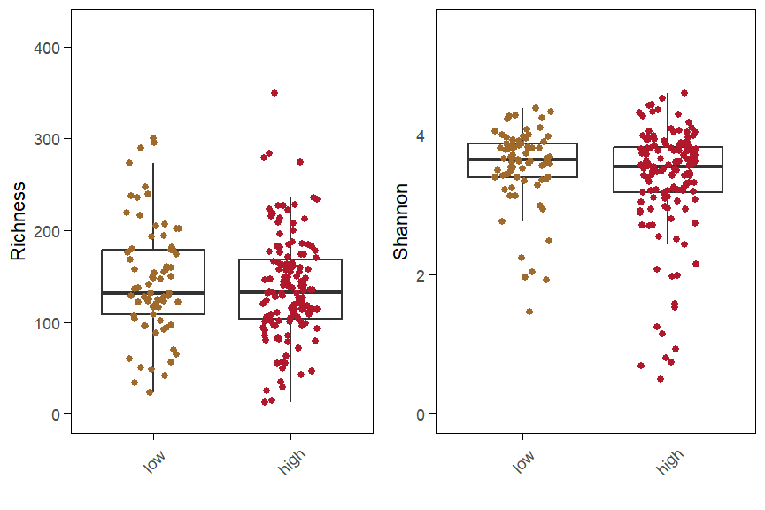

```r
p_boxplot_alpha <- alpha_diversity_custom_2(alpha_data_nancy)
# save the results
alpha_div_plots_nancy[[paste(segment,"Custom")]] <- p_boxplot_alpha

# see the results
p_boxplot_alpha
```

## Beta diversity

### Main analysis

**Genus level, Aitchison distance**

```r
level="genus"
```

```r
path = "../results/Q4/beta_diversity"
```

Aggregation, filtering

```r
# Aggregation
genus_data <- aggregate_taxa(colon_asv_tab,
                             colon_taxa_tab,
                             taxonomic_level=level,
                             names=TRUE)
# Filtration
filt_data <- filtering_steps(genus_data[[1]],
                             genus_data[[2]],
                             colon_metadata,
                             seq_depth_threshold=10000)
```

```
Removing 30 ASV(s)
```

```r
filt_colon_genus_tab <- filt_data[[1]]
filt_colon_genus_taxa <- filt_data[[2]]
filt_colon_metadata <- filt_data[[3]]

filt_colon_metadata %<>% dplyr::mutate(Group=Nancy)
```

##### Plots

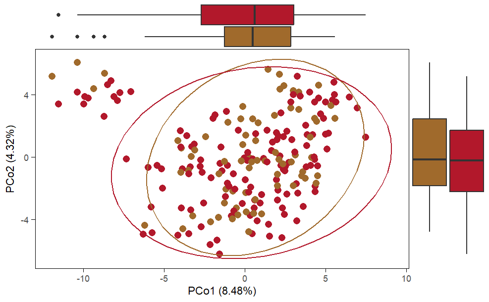

```r
p <- pca_plot_custom(filt_colon_genus_tab,
                                 filt_colon_genus_taxa,
                                 filt_colon_metadata,
                                 show_boxplots = TRUE,
                                 variable = "Group", size=3, show_legend=FALSE)

# save the results
pca_plots_list_nancy[[paste(segment,level,"custom")]] <- p

# see the results
p
```

# Fecal calprotectin

## Data Import

Importing ASV, taxa and metadata tables for both Czech and Norway samples.

**Czech**

*MICROBIOME*

```r
path = "../../data/analysis_ready_data/ikem/"
asv_tab_ikem <- as.data.frame(fread(file.path(path,"asv_table_ikem.csv"),
                                    check.names = FALSE))
taxa_tab_ikem <- as.data.frame(fread(file.path(path,"taxa_table_ikem.csv"),
                                     check.names = FALSE))
metadata_ikem <- as.data.frame(fread(file.path(path,"metadata_ikem.csv"),
                                     check.names = FALSE))
```

*Fecal calprotectin info*

```r
# clinical metadata
metadata_clinical <- read.csv("../../data/clinical_data/clinical_metadata_cz.csv")
metadata_clinical$PatientID <- as.character(metadata_clinical$PatientID)
```

**Norway**

*MICROBIOME*

```r
path = "../../data/analysis_ready_data/norway/"
asv_tab_norway <- as.data.frame(fread(file.path(path,"asv_table_norway.csv"),
                                    check.names = FALSE))
taxa_tab_norway <- as.data.frame(fread(file.path(path,"taxa_table_norway.csv"),
                                    check.names = FALSE))
metadata_norway <- as.data.frame(fread(file.path(path,"metadata_norway.csv"),
                                    check.names = FALSE))
```

*Fecal calprotectin info*

```r
# clinical metadata
metadata_clinical_no <- read.csv("../../data/clinical_data/clinical_metadata_no.csv")
metadata_clinical_no$PatientID <- paste0("NO_", as.character(metadata_clinical_no$subjectid))
```

### Merging

**Clinical data**

```r
metadata_ikem <- merge(metadata_ikem,metadata_clinical[,c("SampleID","Fecal.calprotectin")],by="SampleID",all.x=TRUE) %>%
  dplyr::mutate(Calprotectin=Fecal.calprotectin) %>%
  dplyr::mutate(Calprotectin = case_when(
        Calprotectin == ">6000" ~ "6000",
        TRUE ~ Calprotectin)) %>%
  dplyr::mutate(Calprotectin= as.numeric(Calprotectin))

metadata_norway <- merge(metadata_norway,metadata_clinical_no[,c("SampleID","Calprotectin")],
                         by="SampleID",all.x=TRUE) %>%
  dplyr::mutate(Calprotectin= as.numeric(Calprotectin))
```

**Terminal ileum**

```r
ileum_data <- merging_data(asv_tab_1=asv_tab_ikem,
                           asv_tab_2= asv_tab_norway,
                           taxa_tab_1=taxa_tab_ikem,
                           taxa_tab_2=taxa_tab_norway,
                           metadata_1=metadata_ikem,
                           metadata_2=metadata_norway,
                           segment="TI",Q="Q5")
```

```
Removing 1498 ASV(s)
Removing 1834 ASV(s)
Merging at ASV level
Finding inconsistencies in taxonomy, trying to keep the ones that have better taxonomy assignment
```

```r
ileum_asv_tab <- ileum_data[[1]]
ileum_taxa_tab <- ileum_data[[2]]
ileum_metadata <- ileum_data[[3]]
```

```r
ileum_metadata %<>%  dplyr::mutate(
  log_Calprotectin=log(Calprotectin,base = 10))

median(ileum_metadata$Calprotectin,na.rm = TRUE)
```

```
[1] 129.5
```

```r
median(ileum_metadata$log_Calprotectin,na.rm = TRUE)
```

```
[1] 2.112007
```

```r
p1 <- ggplot(ileum_metadata,aes(log_Calprotectin)) +
  geom_histogram() +
  geom_vline(xintercept = log(250,base=10), linetype="dashed",
               color = "red")
```

*Splitting to groups*

```r
ileum_metadata %<>% dplyr::mutate(Calprotectin_groups = case_when(
    Calprotectin <= 250 ~ "low",
    Calprotectin > 250 ~ "high"))

ileum_metadata %>% group_by(Calprotectin_groups) %>%
  count()
```

| Calprotectin_groups | n |
| --- | --- |
| high | 68 |
| low | 120 |
| NA | 106 |

```r
ileum_metadata %<>% drop_na(Calprotectin) %>% dplyr::filter(Group!="healthy")
ileum_asv_tab %<>% dplyr::select("SeqID",ileum_metadata$SampleID)
ileum_taxa_tab %<>% dplyr::filter(SeqID %in% ileum_asv_tab$SeqID)
```

**Colon**

```r
colon_data <- merging_data(asv_tab_1=asv_tab_ikem,
                           asv_tab_2=asv_tab_norway,
                           taxa_tab_1=taxa_tab_ikem,
                           taxa_tab_2=taxa_tab_norway,
                           metadata_1=metadata_ikem,
                           metadata_2=metadata_norway,
                           segment="colon",Q="Q5")
```

```
Removing 739 ASV(s)
Removing 266 ASV(s)
Merging at ASV level
Finding inconsistencies in taxonomy, trying to keep the ones that have better taxonomy assignment
```

```r
colon_asv_tab <- colon_data[[1]]
colon_taxa_tab <- colon_data[[2]]
colon_metadata <- colon_data[[3]]
```

*Splitting to groups*

```r
colon_metadata %<>% dplyr::mutate(Calprotectin_groups = case_when(
    Calprotectin <= 250 ~ "low",
    Calprotectin > 250 ~ "high"))
```

```r
colon_metadata %<>% drop_na(Calprotectin) %>% dplyr::filter(Group!="healthy")

colon_asv_tab %<>% dplyr::select("SeqID",colon_metadata$SampleID)
colon_taxa_tab %<>% dplyr::filter(SeqID %in% colon_asv_tab$SeqID)
```

# Data Analysis - Terminal ileum

```r
segment="terminal_ileum"
```

## Filtering

Rules:

- sequencing depth > 10000
- nearZeroVar() with default settings

**Rarefaction Curve**

```r
path="../intermediate_files/rarecurves"
seq_depth_threshold <- 10000
```

```r
ps <- construct_phyloseq(ileum_asv_tab,ileum_taxa_tab,ileum_metadata)
rareres <- get_rarecurve(obj=ps, chunks=500)
save(rareres,file = file.path(path,"rarefaction_ileum.Rdata"))
```

```r
load(file.path(path,"rarefaction_ileum.Rdata"))

prare <- ggrarecurve(obj=rareres,
                      factorNames="Country",
                      indexNames=c("Observe")) +
  theme_bw() +
  theme(axis.text=element_text(size=8), panel.grid=element_blank(),
        strip.background = element_rect(colour=NA,fill="grey"),
        strip.text.x = element_text(face="bold")) +
  geom_vline(xintercept = seq_depth_threshold,
             linetype="dashed",
             color = "red") +
  xlim(0, 20000)
```

```
The color has been set automatically, you can reset it manually by adding scale_color_manual(values=yourcolors)
```

```r
prare
```

[output not shown]

**Library size**

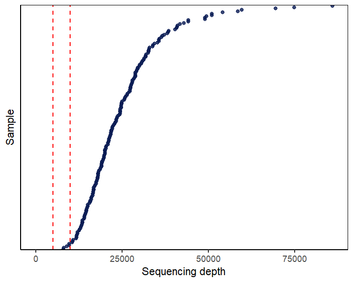

```r
read_counts(ileum_asv_tab, line = c(5000,10000))
```

### Sequencing depth

```r
data_filt <- seq_depth_filtering(ileum_asv_tab,
                                 ileum_taxa_tab,
                                 ileum_metadata,
                                 seq_depth_threshold = 10000)
```

```
Removing 1206 ASV(s)
```

```r
filt_ileum_asv_tab <- data_filt[[1]]; alpha_ileum_asv_tab <- filt_ileum_asv_tab
filt_ileum_taxa_tab <- data_filt[[2]]; alpha_ileum_taxa_tab <- filt_ileum_taxa_tab
filt_ileum_metadata <- data_filt[[3]]; alpha_ileum_metadata <- filt_ileum_metadata

seq_step <- dim(filt_ileum_asv_tab)[1]
```

**Library size**

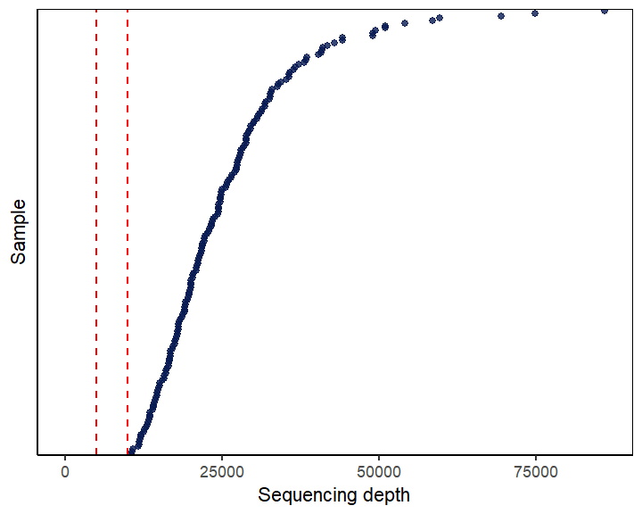

```r
read_counts(filt_ileum_asv_tab,line = c(5000,10000))
```

### NearZeroVar

```r
data_filt <- nearzerovar_filtering(filt_ileum_asv_tab,
                                   filt_ileum_taxa_tab,
                                   filt_ileum_metadata)

filt_ileum_asv_tab <- data_filt[[1]]
filt_ileum_taxa_tab <- data_filt[[2]]
nearzero_step <- dim(filt_ileum_asv_tab)[1]
```

Library size

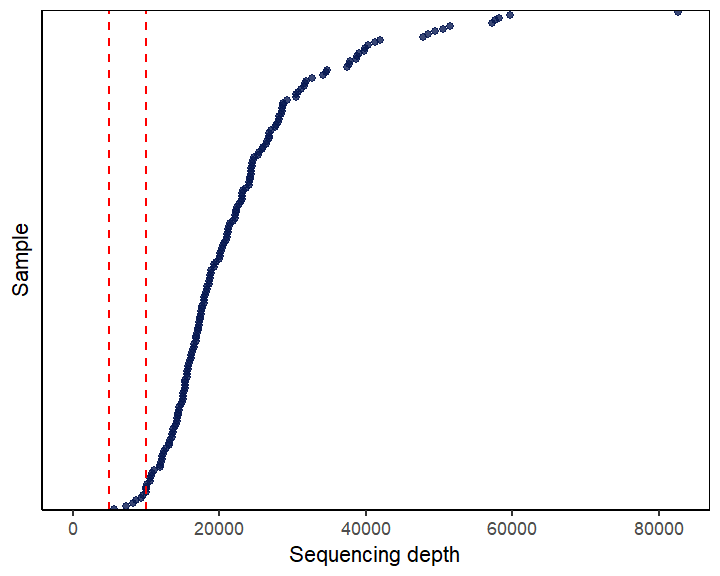

```r
read_counts(filt_ileum_asv_tab,line = c(5000,10000))
```

### Final Counts

```r
final_counts_filtering(ileum_asv_tab,
                       filt_ileum_asv_tab,
                       filt_ileum_metadata,
                       seq_step, 0, nearzero_step) %>% `colnames<-`("Count")
```

|  | Count |
| --- | --- |
| Raw data: ASVs | 5132 |
| Raw data: Samples | 187 |
| Sequencing depth filt: ASVs | 3926 |
| Prevalence filt: ASVs | 0 |
| NearZeroVar filt: ASVs | 651 |
| Filt data: ASVs | 651 |
| Filt data: Samples | 182 |
| Filt data: Patients | 182 |
| Filt data: Patients.1 | 0 |
| Filtered samples | 5 |

[output cut: 7 more lines]

## Alpha diversity

```r
path = "../results/Q5/alpha_diversity"
```

**Calculation**

```r
# Construct MPSE object
alpha_ileum_metadata$Sample <- alpha_ileum_metadata$SampleID
ileum_mpse <- as.MPSE(construct_phyloseq(alpha_ileum_asv_tab,
                                         alpha_ileum_taxa_tab,
                                         alpha_ileum_metadata))

ileum_mpse %<>% mp_rrarefy(raresize = 10000,seed = 123)

# Calculate alpha diversity - rarefied counts
ileum_mpse %<>% mp_cal_alpha(.abundance=RareAbundance, force=TRUE)
```

```r
alpha_div_plots_cal <- list()

# preparing data frame
alpha_data_cal <- data.frame(SampleID=ileum_mpse$Sample.x,
                         Observe=ileum_mpse$Observe,
                         Shannon=ileum_mpse$Shannon,
                         Simpson=ileum_mpse$Simpson,
                         Pielou=ileum_mpse$Pielou,
                         Group=ileum_mpse$Calprotectin_groups,
                         Country=ileum_mpse$Country,
                         Patient=ileum_mpse$Patient)

alpha_data_cal %<>% drop_na()
```

### Plots

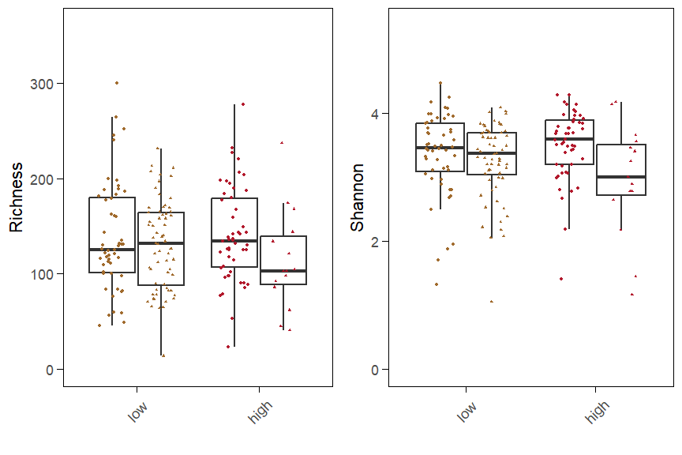

```r
p_boxplot_alpha <- alpha_diversity_countries(alpha_data_cal)
# save the results
alpha_div_plots_cal[[paste(segment,"Country")]] <- p_boxplot_alpha

# see the results
p_boxplot_alpha
```

## Beta diversity

Calculating Aitchison distance (euclidean distance on clr-transformed data), both at ASV and genus level.

### Main analysis

**Genus level, Aitchison distance**

```r
level="genus"
```

```r
path = "../results/Q5/beta_diversity"
```

```r
pca_plots_list_cal <- list()
```

Aggregation, filtering

```r
# Aggregation
genus_data <- aggregate_taxa(ileum_asv_tab,
                             ileum_taxa_tab,
                             taxonomic_level=level,
                             names=TRUE)
# Filtration
filt_data <- filtering_steps(genus_data[[1]],
                             genus_data[[2]],
                             ileum_metadata,
                             seq_depth_threshold=10000)
```

```
Removing 56 ASV(s)
```

```r
filt_ileum_genus_tab <- filt_data[[1]]
filt_ileum_genus_taxa <- filt_data[[2]]
filt_ileum_metadata <- filt_data[[3]] %>% dplyr::mutate(Group=Calprotectin_groups)
```

##### Plots

**PCA**

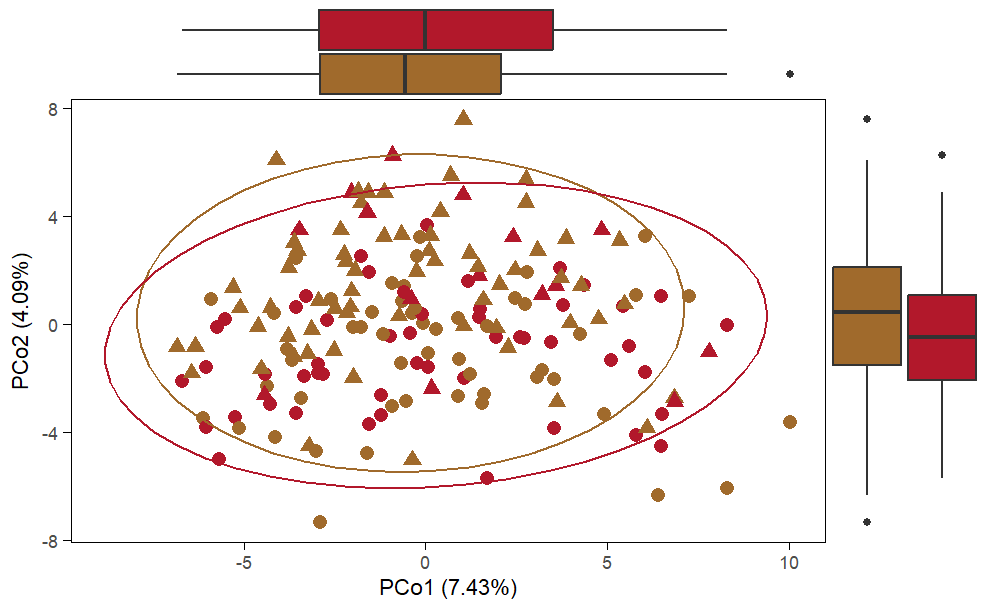

```r
p <- pca_plot_custom(filt_ileum_genus_tab,
                                 filt_ileum_genus_taxa,
                                 filt_ileum_metadata,
                                 show_boxplots = TRUE,
                                 variable = "Group", size=3, show_legend=FALSE)

# save the results
pca_plots_list_cal[[paste(segment,level,"custom")]] <- p

# see the results
p
```

# Data Analysis - Colon

```r
segment="colon"
```

## Filtering

Rules:

- sequencing depth > 10000
- nearZeroVar() with default settings

**Rarefaction Curve**

```r
path="../intermediate_files/rarecurves"
seq_depth_threshold <- 10000
```

```r
ps <- construct_phyloseq(colon_asv_tab,colon_taxa_tab,colon_metadata)
rareres <- get_rarecurve(obj=ps, chunks=500)
save(rareres,file = file.path(path,"rarefaction_colon.Rdata"))
```

```r
load(file.path(path,"rarefaction_colon.Rdata"))

prare <- ggrarecurve(obj=rareres,
                      factorNames="Country",
                      indexNames=c("Observe")) +
  theme_bw() +
  theme(axis.text=element_text(size=8), panel.grid=element_blank(),
        strip.background = element_rect(colour=NA,fill="grey"),
        strip.text.x = element_text(face="bold")) +
  geom_vline(xintercept = seq_depth_threshold,
             linetype="dashed",
             color = "red") +
  xlim(0, 20000)
```

```
The color has been set automatically, you can reset it manually by adding scale_color_manual(values=yourcolors)
```

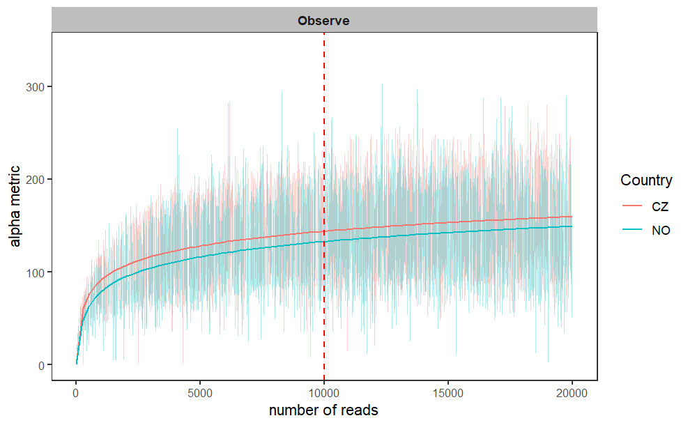

```r
prare
```

**Library size**

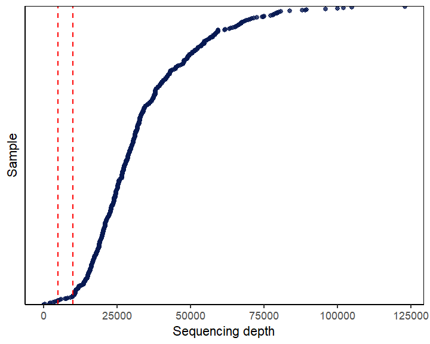

```r
read_counts(colon_asv_tab, line = c(5000,10000))
```

### Sequencing depth

```r
data_filt <- seq_depth_filtering(colon_asv_tab,
                                 colon_taxa_tab,
                                 colon_metadata,
                                 seq_depth_threshold = 10000)
```

```
Removing 1498 ASV(s)
```

```r
filt_colon_asv_tab <- data_filt[[1]]; alpha_colon_asv_tab <- filt_colon_asv_tab
filt_colon_taxa_tab <- data_filt[[2]]; alpha_colon_taxa_tab <- filt_colon_taxa_tab
filt_colon_metadata <- data_filt[[3]]; alpha_colon_metadata <- filt_colon_metadata

seq_step <- dim(filt_colon_asv_tab)[1]
```

**Library size**

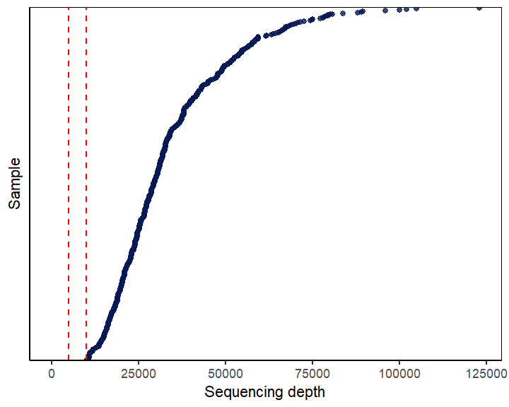

```r
read_counts(filt_colon_asv_tab,line = c(5000,10000))
```

### NearZeroVar

```r
data_filt <- nearzerovar_filtering(filt_colon_asv_tab,
                                   filt_colon_taxa_tab,
                                   filt_colon_metadata)

filt_colon_asv_tab <- data_filt[[1]]
filt_colon_taxa_tab <- data_filt[[2]]
nearzero_step <- dim(filt_colon_asv_tab)[1]
```

Library size

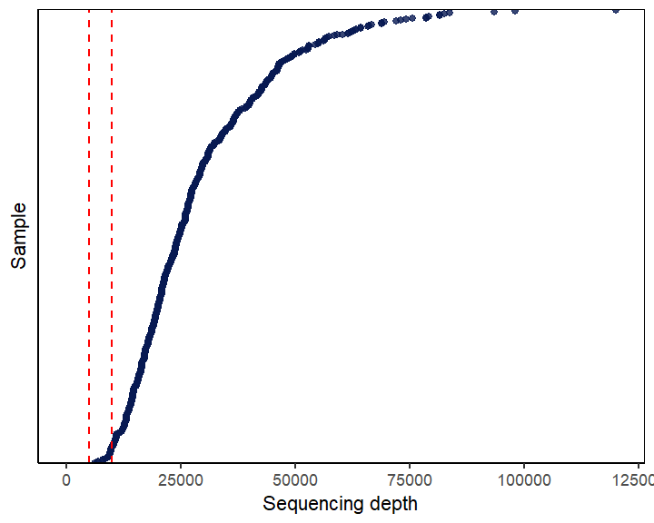

```r
read_counts(filt_colon_asv_tab,line = c(5000,10000))
```

### Final Counts

```r
final_counts_filtering(colon_asv_tab,
                       filt_colon_asv_tab,
                       filt_colon_metadata,
                       seq_step, 0, nearzero_step) %>% `colnames<-`("Count")
```

|  | Count |
| --- | --- |
| Raw data: ASVs | 6936 |
| Raw data: Samples | 544 |
| Sequencing depth filt: ASVs | 5438 |
| Prevalence filt: ASVs | 0 |
| NearZeroVar filt: ASVs | 369 |
| Filt data: ASVs | 369 |
| Filt data: Samples | 528 |
| Filt data: Patients | 228 |
| Filt data: Patients.1 | 0 |
| Filtered samples | 16 |

[output cut: 7 more lines]

## Alpha diversity

```r
path = "../results/Q5/alpha_diversity"
```

**Calculation**

```r
# Construct MPSE object
alpha_colon_metadata$Sample <- alpha_colon_metadata$SampleID
colon_mpse <- as.MPSE(construct_phyloseq(alpha_colon_asv_tab,
                                         alpha_colon_taxa_tab,
                                         alpha_colon_metadata))

colon_mpse %<>% mp_rrarefy(raresize = 10000,seed = 123)

# Calculate alpha diversity - rarefied counts
colon_mpse %<>% mp_cal_alpha(.abundance=RareAbundance, force=TRUE)
```

```r
# preparing data frame
alpha_data_cal <- data.frame(SampleID=colon_mpse$Sample.x,
                         Observe=colon_mpse$Observe,
                         Shannon=colon_mpse$Shannon,
                         Simpson=colon_mpse$Simpson,
                         Pielou=colon_mpse$Pielou,
                         Group=colon_mpse$Calprotectin_groups,
                         Country=colon_mpse$Country,
                         Patient=colon_mpse$Patient)

alpha_data_cal %<>% drop_na()
```

### Plots

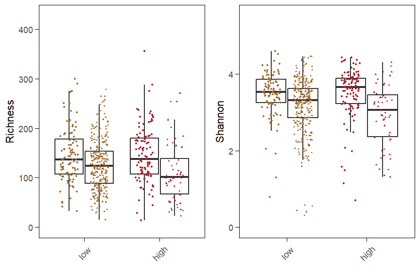

```r
p_boxplot_alpha <- alpha_diversity_countries(alpha_data_cal)
# save the results
alpha_div_plots_cal[[paste(segment,"Countries")]] <- p_boxplot_alpha

# see the results
p_boxplot_alpha
```

## Beta diversity

Calculating Aitchison distance (euclidean distance on clr-transformed data), both at ASV and genus level.

### Main analysis

**Genus level, Aitchison distance**

```r
level="genus"
```

```r
path = "../results/Q5/beta_diversity"
```

Aggregation, filtering

```r
# Aggregation
genus_data <- aggregate_taxa(colon_asv_tab,
                             colon_taxa_tab,
                             taxonomic_level=level,
                             names=TRUE)
# Filtration
filt_data <- filtering_steps(genus_data[[1]],
                             genus_data[[2]],
                             colon_metadata,
                             seq_depth_threshold=10000)
```

```
Removing 43 ASV(s)
```

```r
filt_colon_genus_tab <- filt_data[[1]]
filt_colon_genus_taxa <- filt_data[[2]]
filt_colon_metadata <- filt_data[[3]]

filt_colon_metadata %<>% dplyr::mutate(Group=Calprotectin_groups)
```

##### Plots

**PCoA custom**

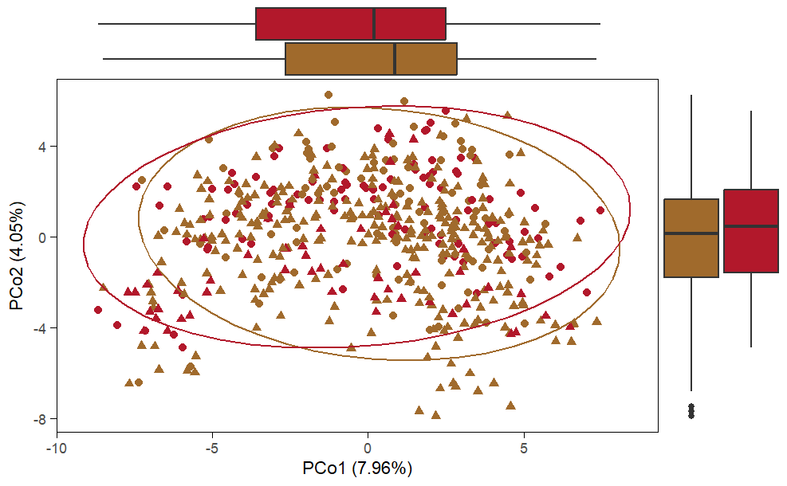

```r
p <- pca_plot_custom(filt_colon_genus_tab,
                                 filt_colon_genus_taxa,
                                 filt_colon_metadata,
                                 show_boxplots = TRUE,
                                 variable = "Group", size=2,
                                 show_legend=FALSE)

# save the results
pca_plots_list_cal[[paste(segment,level,"custom")]] <- p

# see the results
p
```

# Paper-ready visualizations

## Alpha diversity

### IBD

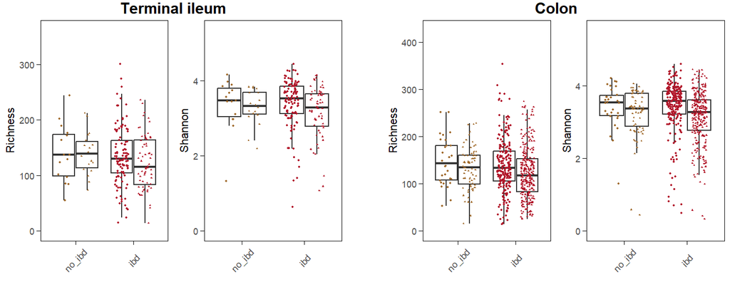

```r
p_A <- alpha_div_plots_ibd$`terminal_ileum Country` +
  ggtitle("Terminal ileum")+
  theme(plot.title = element_text(hjust=0.5,face = "bold",size = 15))

p_B <-  alpha_div_plots_ibd$`colon Country` +
  ggtitle("Colon") +
  theme(plot.title = element_text(hjust=0.5,face = "bold",size = 15))

ibd_alpha <- ggarrange(p_A,ggplot() + theme_minimal(),p_B,nrow=1, ncol=3,
                      widths = c(1,0.1,1))
ibd_alpha
```

### Nancy

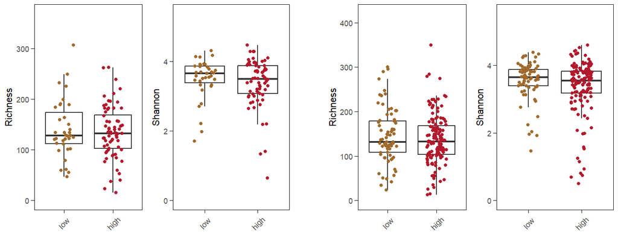

```r
p_A <- alpha_div_plots_nancy$`terminal_ileum Custom`

p_B <-  alpha_div_plots_nancy$`colon Custom`

nancy_alpha <- ggarrange(p_A,ggplot() + theme_minimal(),p_B,nrow=1, ncol=3,
                      widths = c(1,0.1,1))
nancy_alpha
```

### Calprotectin

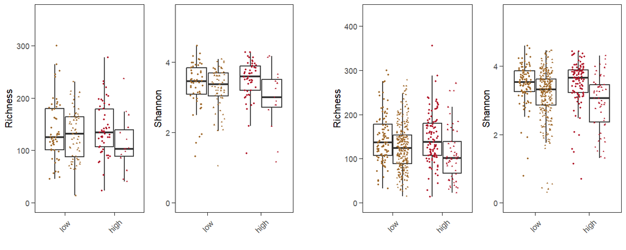

```r
p_A <- alpha_div_plots_cal$`terminal_ileum Country`

p_B <-  alpha_div_plots_cal$`colon Countries`

cal_alpha <- ggarrange(p_A,ggplot() + theme_minimal(),p_B,nrow=1, ncol=3,
                      widths = c(1,0.1,1))
cal_alpha
```

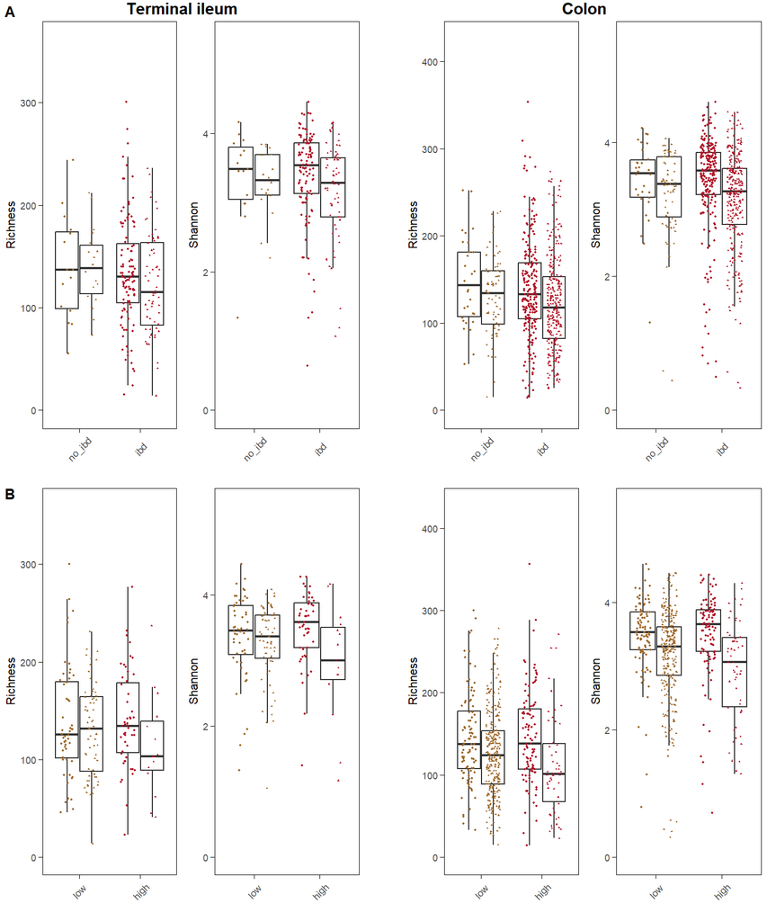

```r
fig_alpha <- ggarrange(ibd_alpha,cal_alpha, ncol=1,heights = c(1.1,1),labels = c("A","B"))
fig_alpha
```

## Beta diversity

### IBD

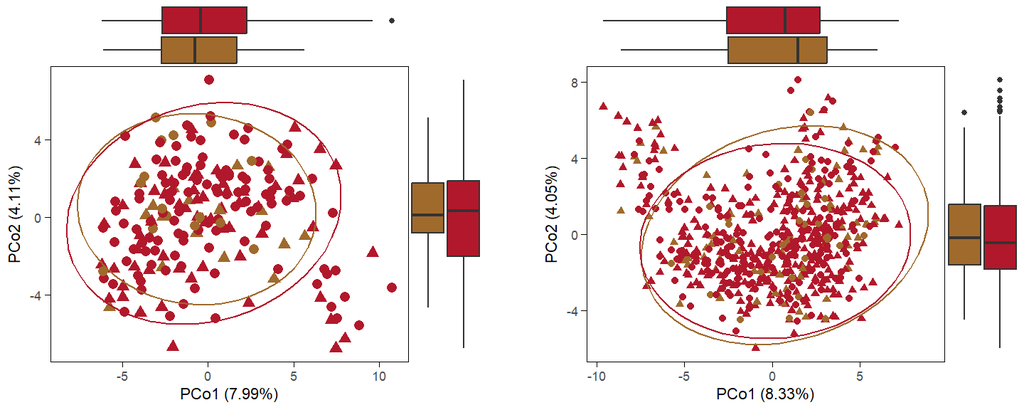

```r
pca_ti <- pca_plots_list_ibd$`terminal_ileum genus custom`
pca_colon <- pca_plots_list_ibd$`colon genus custom`

ibd_beta <- ggarrange(pca_ti,
                           ggplot() + theme_minimal(),
                           pca_colon,ncol=3,
                           widths = c(1,0.1,1))
ibd_beta
```

### Nancy

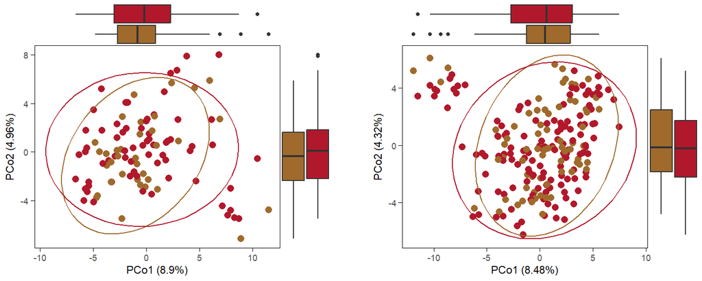

```r
pca_ti <- pca_plots_list_nancy$`terminal_ileum genus custom`
pca_colon <- pca_plots_list_nancy$`colon genus custom`

nancy_beta <- ggarrange(pca_ti,
                           ggplot() + theme_minimal(),
                           pca_colon,ncol=3,
                           widths = c(1,0.1,1))
nancy_beta
```

### Calprotectin

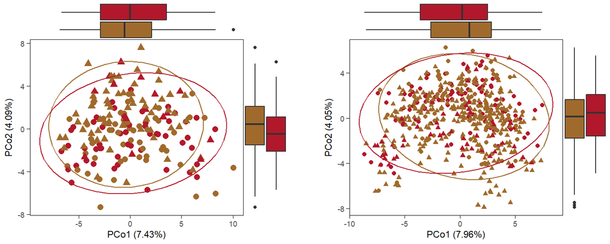

```r
pca_ti <- pca_plots_list_cal$`terminal_ileum genus custom`
pca_colon <- pca_plots_list_cal$`colon genus custom`

cal_beta <- ggarrange(pca_ti,
                           ggplot() + theme_minimal(),
                           pca_colon,ncol=3,
                           widths = c(1,0.1,1))
cal_beta
```

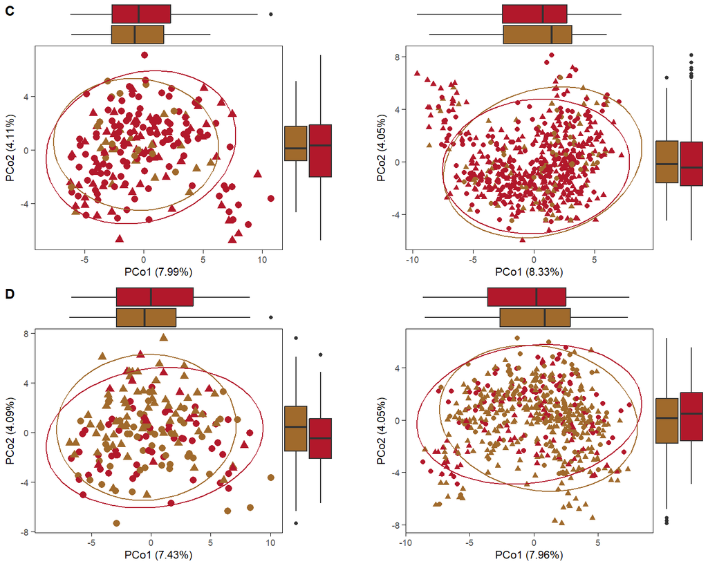

```r
fig_beta <- ggarrange(ibd_beta,cal_beta, ncol=1,labels = c("C","D"))
fig_beta
```

## FIGURE 7

**Alpha + Beta diversity**

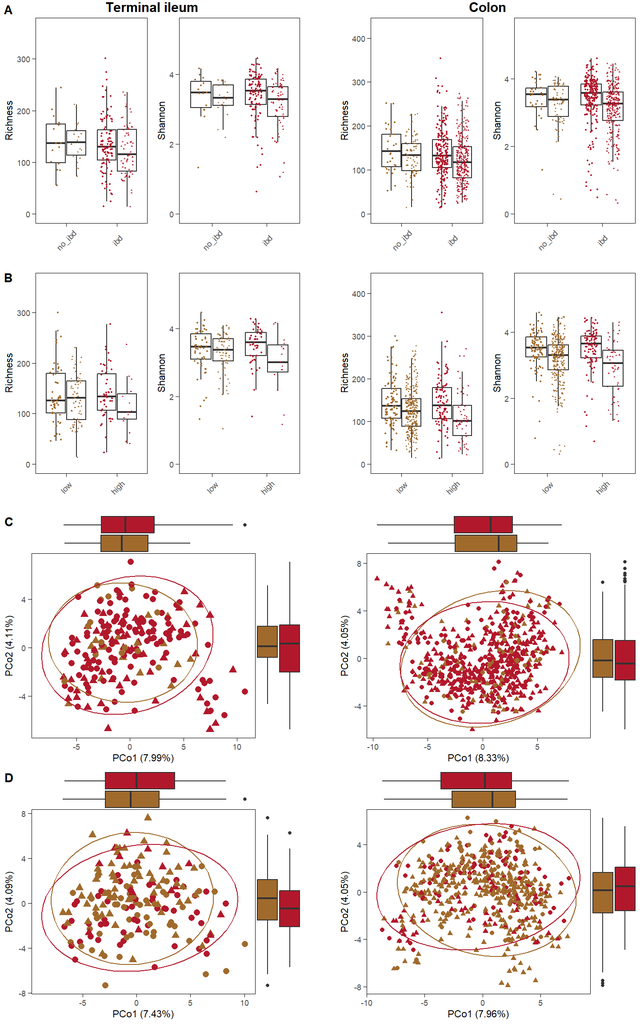

```r
alpha_beta <- ggarrange(fig_alpha,fig_beta,
                        ncol = 1,nrow=2)
alpha_beta
```

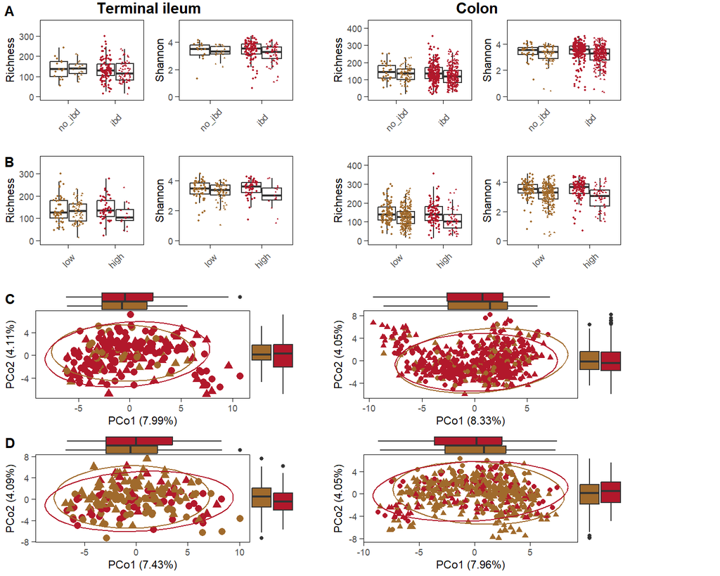

```r
alpha_beta <- ggarrange(alpha_beta,ggplot() + theme_minimal(),ncol=2,
                                widths = c(1,0.15))

alpha_beta
```